# ‘#tidyteusday’ Analysis

# The data was collected from github’s[#Rstats & #TidyTuesday Tweets](https://github.com/rfordatascience/tidytuesday/tree/master/data/2019/2019-01-01).

## Tidytuesday is a weekly data project in R from the R4Ds community, which contains a different dataset each week, today’s data is from April-December 2018, for every tweet that had a “tidytuesday” hashtag.

### Quantitative analysis of tweets

General trend of “tidyteusday” hashtag, a sharp dip in late july might be caused to summer break, increasing to normal counts until end of year break.

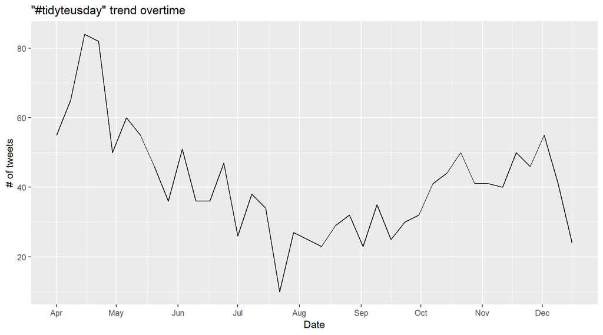

Most #tidytuesday are coming from “Twitter Web Client”, which is normal since most analysis is done on Desktop and laptops.

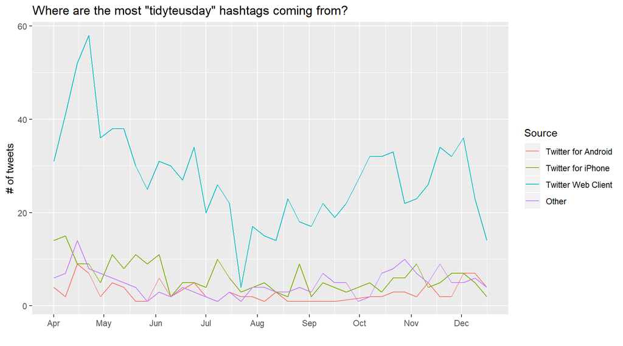

Tidytuesday datasets are submitted on a Monday which explains the gradual increase in tweets to peak on Tuesday and decrease slowly over the weekend.

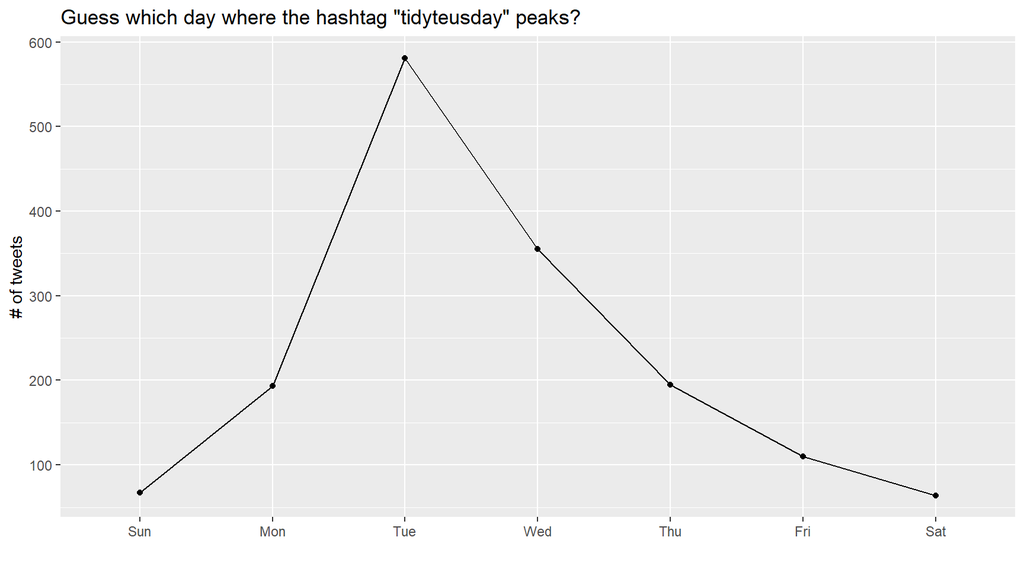

Who are the most influential people on the “tidytuesday” hashtag?

**David Robinson** looks like a clear winner, which I am assuming is attributed to his successful screen-cast of tidytuesday and broadcasting it on twitter.

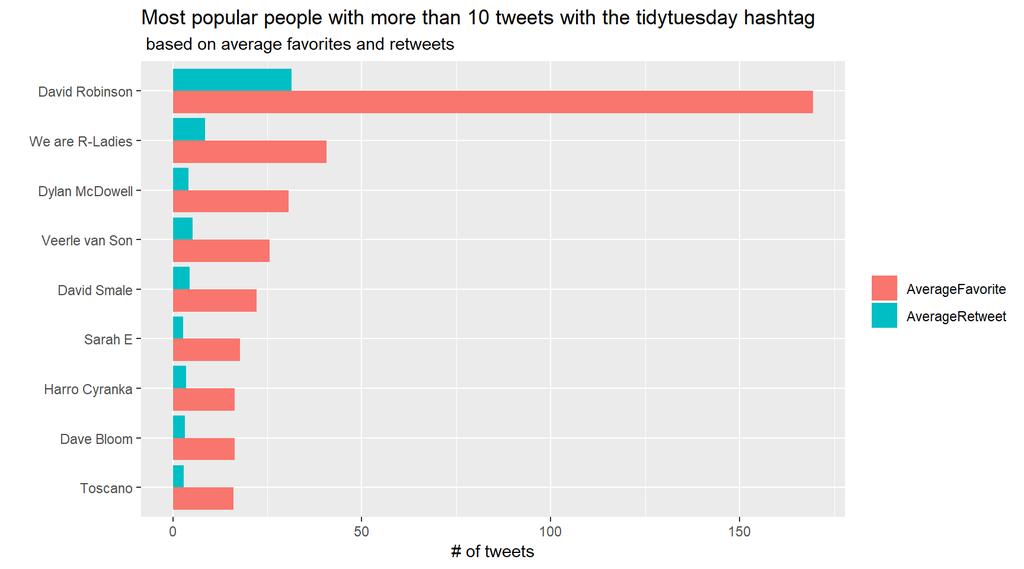

A majority shows an increase in contribution at the start of the year and a decrease at the end of it, this could be contributed to end of year break, or more busy schedules for more successful influencers(A wider data range could answer this problem)

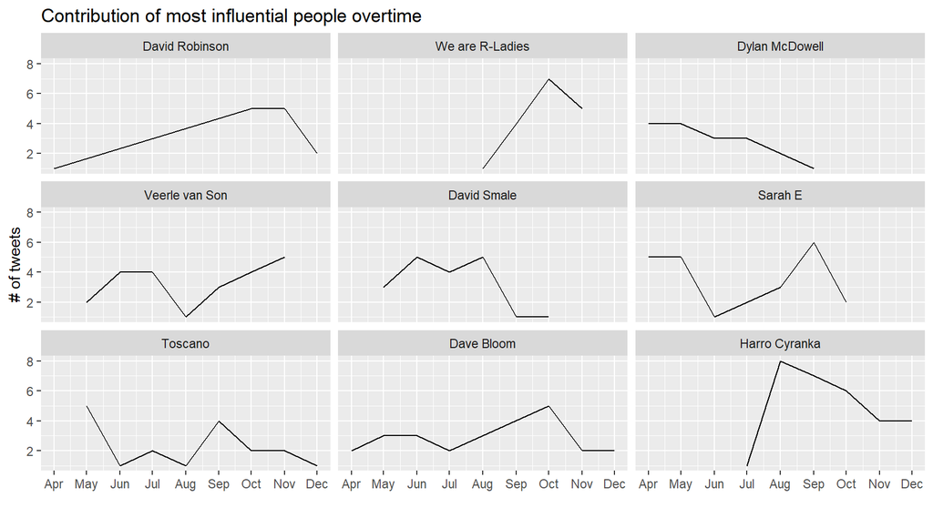

### Text analysis of tweets

Word cloud of most frequently used words in “#tidytuesday” tweets, to no surprise #rstats,data,week and #r4ds are the most accompanied words to #tidytuesday

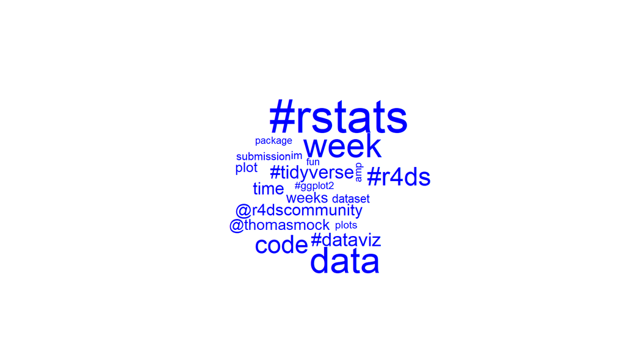

Most popular words used along side the hashtag “tidytuesday” based on average favorite and retweets.

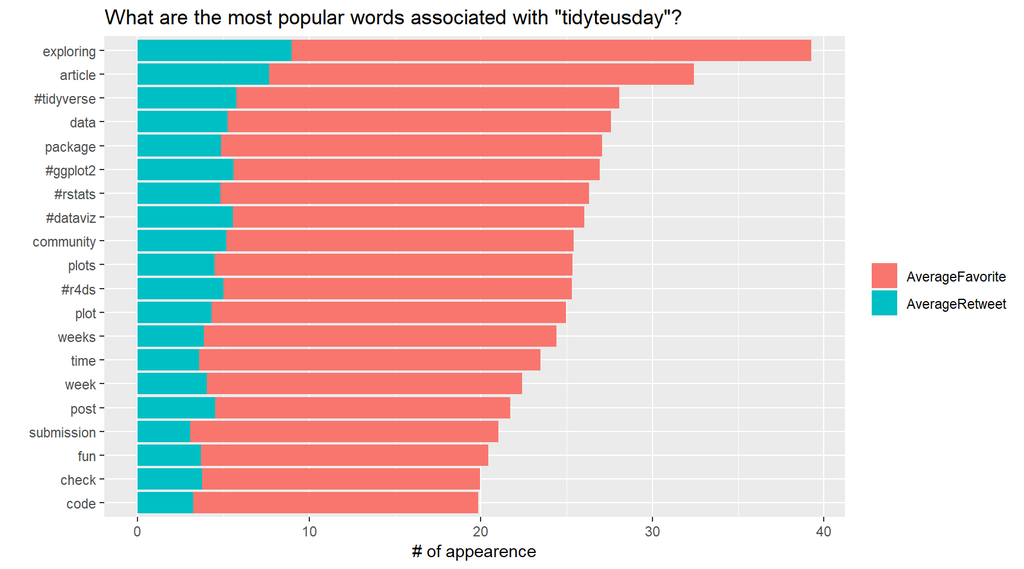

Finally, we explore the flavor of the month, which topics topped the charts?

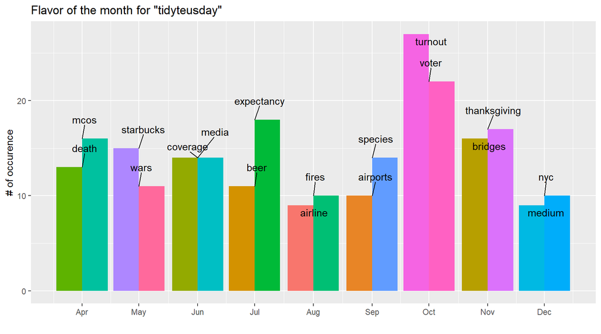